# Final Project - Forecasting US Candy Production

brp107@scarletmail.rutgers.edu

11/23/2026

```r
library(fpp2)
library(forecast)

candy <- read.csv("candy.csv")
candy_ts <- ts(candy$IPG3113N, start = c(1972, 1), frequency = 12)
```

## 1. Exploration

```r
summary(candy_ts)
```

```
##    Min. 1st Qu.  Median    Mean 3rd Qu.    Max.
##   44.22   78.17   91.98   89.65  101.03  125.50
```

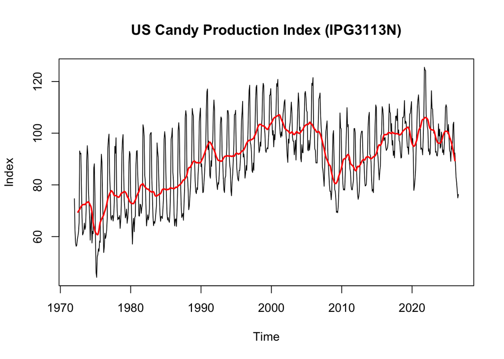

```r
plot(candy_ts, main = "US Candy Production Index (IPG3113N)", ylab = "Index")
lines(ma(candy_ts, order = 12), col = "red", lwd = 2)
```

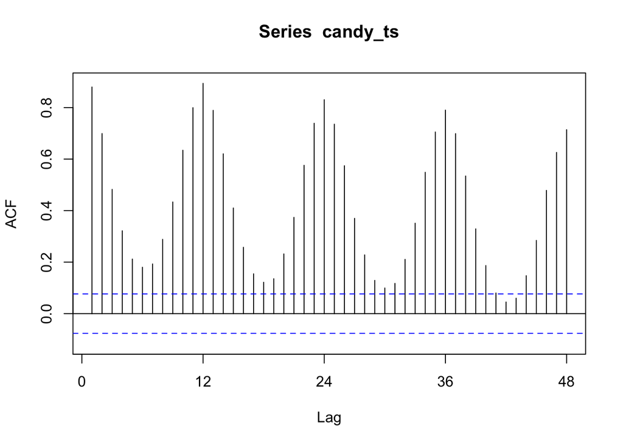

```r
Acf(candy_ts, lag.max = 48)
```

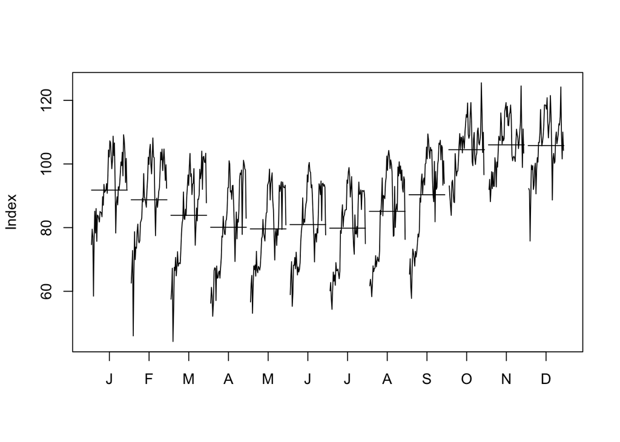

```r
monthplot(candy_ts, ylab = "Index")
```

```r
round(tapply(candy_ts, cycle(candy_ts), mean), 1)
```

```
##     1     2     3     4     5     6     7     8     9    10    11    12
##  91.8  88.7  83.9  80.1  79.6  81.0  79.8  85.1  90.3 104.5 106.0 105.8
```

```r
ndiffs(candy_ts)
```

```
## [1] 1
```

```r
nsdiffs(candy_ts)
```

```
## [1] 1
```

```r
ndiffs(diff(candy_ts, 12))
```

```
## [1] 0
```

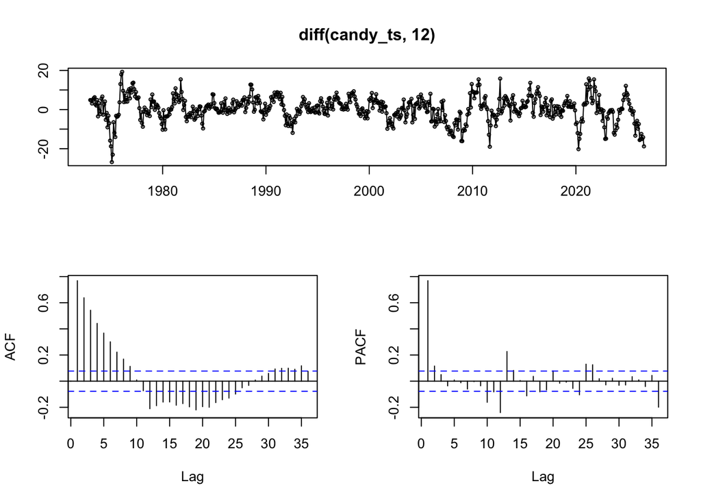

```r
tsdisplay(diff(candy_ts, 12))
```

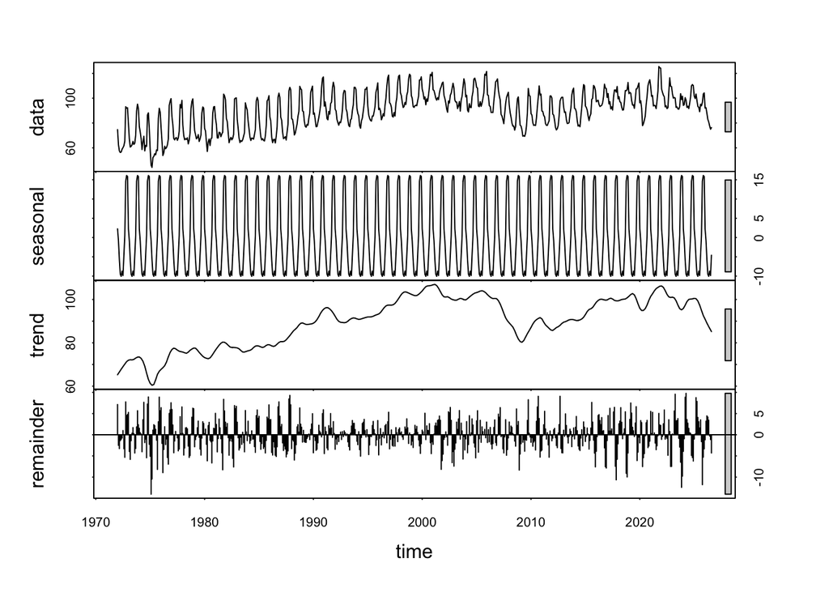

```r
stl_decomp <- stl(candy_ts, s.window = "periodic")
plot(stl_decomp)
```

```r
round(window(stl_decomp$time.series[, "trend"], start = c(2024, 1)), 1)
```

```
##        Jan   Feb   Mar   Apr   May   Jun   Jul   Aug   Sep   Oct   Nov   Dec
## 2024  95.9  96.6  97.3  98.2  99.0  99.5 100.0 100.1 100.2 100.2 100.3 100.4
## 2025 100.5 100.4 100.4  99.8  99.3  98.3  97.4  96.2  95.0  93.8  92.6  91.7
## 2026  90.9  90.0  89.1  88.3  87.5  86.7  86.0  85.2
```

**Insights:** the series has a strong yearly cycle (ACF of 0.89 at lag 12 and 0.83 at lag 24; production is about 26 index points higher in Oct–Dec than in Apr–Jul) and a long-run trend that rose until 2000, fell in 2008–09 and recovered. One seasonal difference makes it stationary (`nsdiffs` = 1, then `ndiffs` = 0). The STL trend peaked at about 100.5 in early 2025 and has fallen every month since, to 85.2 in August 2026. Jan–Aug 2026 output was 14% below Jan–Aug 2025.

## 2. Train / test split

```r
train <- window(candy_ts, end = c(2024, 8))
test  <- window(candy_ts, start = c(2024, 9))
h <- length(test)
```

The models are fit on Jan 1972 – Aug 2024 (632 months) and tested on Sep 2024 – Aug 2026 (24 months, two full seasonal cycles).

## 3. Models

```r
snaive_forecast <- snaive(train, h = h)

HW_model    <- HoltWinters(train)
c(HW_model$alpha, HW_model$beta, HW_model$gamma)
```

```
##       alpha        beta       gamma
## 0.625759742 0.002820359 0.600040893
```

```r
HW_forecast <- forecast(HW_model, h = h)

ets_model    <- ets(train)
ets_model
```

```
## ETS(A,N,A)
##
## Call:
## ets(y = train)
##
##   Smoothing parameters:
##     alpha = 0.6112
##     gamma = 0.2324
##
##   Initial states:
##     l = 72.2725
##     s = 21.0456 18.4713 19.8681 -3.6263 -6.396 -11.9241
##            -8.584 -11.1114 -7.7285 -11.2913 -4.6299 5.9065
##
##   sigma:  3.5632
##
##      AIC     AICc      BIC
## 5697.658 5698.437 5764.391
```

```r
ets_forecast <- forecast(ets_model, h = h)

stl_forecast <- stlf(train, h = h)
stl_forecast$model$method
```

```
## [1] "ETS(A,N,N)"
```

```r
arima_model    <- auto.arima(train, stepwise = FALSE, approximation = FALSE)
arima_model
```

```
## Series: train
## ARIMA(3,0,0)(1,1,1)[12] with drift
##
## Coefficients:
##          ar1     ar2     ar3    sar1     sma1   drift
##       0.7067  0.0586  0.1097  0.2036  -0.8086  0.0511
## s.e.  0.0402  0.0491  0.0402  0.0532   0.0315  0.0229
##
## sigma^2 = 11.17:  log likelihood = -1629.76
## AIC=3273.52   AICc=3273.7   BIC=3304.52
```

```r
arima_forecast <- forecast(arima_model, h = h)

reg_model    <- tslm(train ~ trend + season)
summary(reg_model)$r.squared
```

```
## [1] 0.72036
```

```r
reg_forecast <- forecast(reg_model, h = h)
```

## 4. Forecasts vs actual on the test set

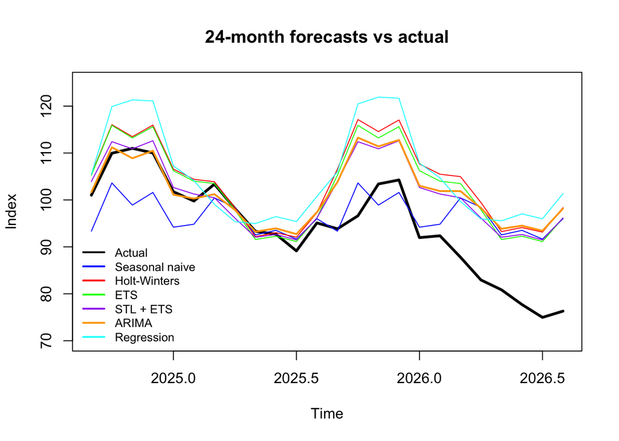

```r
plot(test, ylim = c(70, 125), lwd = 3, main = "24-month forecasts vs actual", ylab = "Index")
lines(snaive_forecast$mean, col = "blue")
lines(HW_forecast$mean, col = "red")
lines(ets_forecast$mean, col = "green")
lines(stl_forecast$mean, col = "purple")
lines(arima_forecast$mean, col = "orange", lwd = 2)
lines(reg_forecast$mean, col = "cyan")
legend("bottomleft", legend = c("Actual", "Seasonal naive", "Holt-Winters", "ETS",
                                "STL + ETS", "ARIMA", "Regression"),
       col = c("black", "blue", "red", "green", "purple", "orange", "cyan"),
       lwd = 2, bty = "n", cex = 0.8)
```

## 5. Accuracy

RMSE is the selection measure: it is in index points, like the data, and it penalizes large misses, which are the costly ones for production planning. MAPE is shown as a percentage for management.

```r
acc_table <- rbind(
  "Seasonal naive" = accuracy(snaive_forecast, test)["Test set", c("RMSE", "MAE", "MAPE", "MASE")],
  "Holt-Winters"   = accuracy(HW_forecast, test)["Test set", c("RMSE", "MAE", "MAPE", "MASE")],
  "ETS"            = accuracy(ets_forecast, test)["Test set", c("RMSE", "MAE", "MAPE", "MASE")],
  "STL + ETS"      = accuracy(stl_forecast, test)["Test set", c("RMSE", "MAE", "MAPE", "MASE")],
  "ARIMA"          = accuracy(arima_forecast, test)["Test set", c("RMSE", "MAE", "MAPE", "MASE")],
  "Regression"     = accuracy(reg_forecast, test)["Test set", c("RMSE", "MAE", "MAPE", "MASE")]
)
round(acc_table, 2)
```

```
##                 RMSE   MAE  MAPE MASE
## Seasonal naive  9.03  6.94  7.86 1.53
## Holt-Winters   11.64  9.35 10.54 2.06
## ETS            10.52  8.42  9.48 1.85
## STL + ETS       9.28  7.08  8.13 1.56
## ARIMA          10.13  7.44  8.63 1.64
## Regression     13.30 11.46 12.68 2.52
```

One 24-month test is dominated by the 2026 drop, so each model is also tested on ten separate years: train through August of year *k*, forecast the next 12 months, for *k* = 2016 to 2025.

```r
rolling <- NULL
for (k in 2016:2025) {
  tr <- window(candy_ts, end = c(k, 8))
  te <- window(candy_ts, start = c(k, 9), end = c(k + 1, 8))
  f <- list(
    "Seasonal naive" = snaive(tr, h = 12)$mean,
    "Holt-Winters"   = forecast(HoltWinters(tr), h = 12)$mean,
    "ETS"            = forecast(ets(tr), h = 12)$mean,
    "STL + ETS"      = stlf(tr, h = 12)$mean,
    "ARIMA"          = forecast(auto.arima(tr), h = 12)$mean,
    "Regression"     = forecast(tslm(tr ~ trend + season), h = 12)$mean
  )
  rolling <- rbind(rolling, sapply(f, function(p) sqrt(mean((as.numeric(te) - as.numeric(p))^2))))
}
rownames(rolling) <- paste0(2016:2025, "-", 2017:2026)
round(rolling, 2)
```

```
##           Seasonal naive Holt-Winters   ETS STL + ETS ARIMA Regression
## 2016-2017           2.96         3.79  3.95      3.89  3.26       5.60
## 2017-2018           2.84         5.58  5.25      4.75  3.79       6.82
## 2018-2019           3.19         4.00  4.29      4.38  4.39       6.39
## 2019-2020           9.60         9.41  9.12      8.43  8.57       9.79
## 2020-2021           9.10         5.61  6.16      7.73  8.56       4.16
## 2021-2022           6.95         6.72  6.97      7.41  6.78       4.29
## 2022-2023           6.91         4.29  4.51      4.34  3.40       6.26
## 2023-2024           7.18         7.08  7.17      6.29  6.24      11.74
## 2024-2025           5.88         3.63  3.37      1.94  1.58       6.53
## 2025-2026          12.51        13.93 12.90     12.15 12.89      17.29
```

```r
round(colMeans(rolling), 2)
```

```
## Seasonal naive   Holt-Winters            ETS      STL + ETS          ARIMA
##           6.71           6.40           6.37           6.13           5.95
##     Regression
##           7.89
```

## 6. Residual analysis

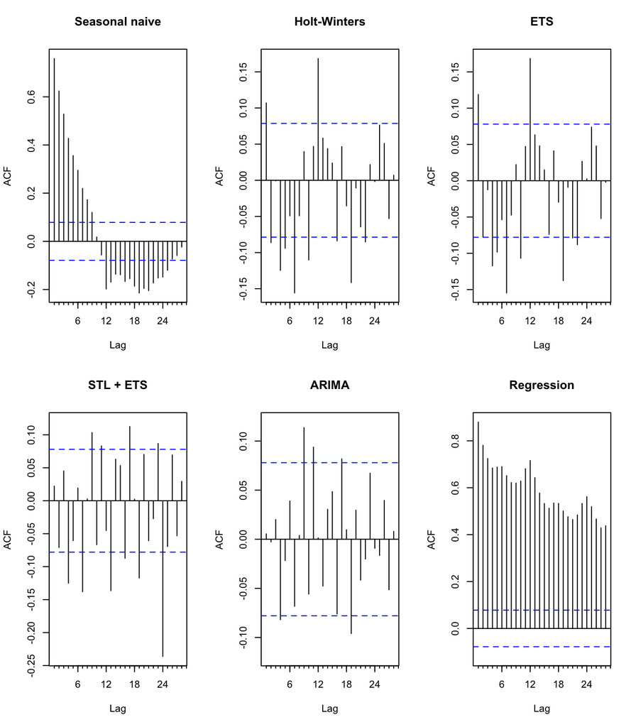

```r
par(mfrow = c(2, 3))
Acf(residuals(snaive_forecast), main = "Seasonal naive")
Acf(residuals(HW_forecast), main = "Holt-Winters")
Acf(residuals(ets_forecast), main = "ETS")
Acf(residuals(stl_forecast), main = "STL + ETS")
Acf(residuals(arima_forecast), main = "ARIMA")
Acf(residuals(reg_forecast), main = "Regression")
```

```r
par(mfrow = c(1, 1))

Box.test(residuals(snaive_forecast), lag = 24, type = "Ljung")
```

```
##
##  Box-Ljung test
##
## data:  residuals(snaive_forecast)
## X-squared = 1337, df = 24, p-value < 2.2e-16
```

```r
Box.test(residuals(HW_forecast), lag = 24, type = "Ljung", fitdf = 3)
```

```
##
##  Box-Ljung test
##
## data:  residuals(HW_forecast)
## X-squared = 104.42, df = 21, p-value = 4.732e-13
```

```r
Box.test(residuals(ets_forecast), lag = 24, type = "Ljung", fitdf = 2)
```

```
##
##  Box-Ljung test
##
## data:  residuals(ets_forecast)
## X-squared = 105.51, df = 22, p-value = 6.932e-13
```

```r
Box.test(residuals(stl_forecast), lag = 24, type = "Ljung", fitdf = 1)
```

```
##
##  Box-Ljung test
##
## data:  residuals(stl_forecast)
## X-squared = 131.63, df = 23, p-value < 2.2e-16
```

```r
Box.test(residuals(arima_forecast), lag = 24, type = "Ljung", fitdf = 5)
```

```
##
##  Box-Ljung test
##
## data:  residuals(arima_forecast)
## X-squared = 47.651, df = 19, p-value = 0.000288
```

```r
Box.test(residuals(reg_forecast), lag = 24, type = "Ljung")
```

```
##
##  Box-Ljung test
##
## data:  residuals(reg_forecast)
## X-squared = 5984.4, df = 24, p-value < 2.2e-16
```

## 7. Final model and forecast

```r
final_fit <- auto.arima(candy_ts, stepwise = FALSE, approximation = FALSE)
final_fit
```

```
## Series: candy_ts
## ARIMA(3,0,0)(1,1,1)[12]
##
## Coefficients:
##          ar1     ar2     ar3    sar1     sma1
##       0.7202  0.0609  0.1212  0.2017  -0.8087
## s.e.  0.0397  0.0485  0.0396  0.0516   0.0302
##
## sigma^2 = 11.25:  log likelihood = -1695.63
## AIC=3403.26   AICc=3403.39   BIC=3430.07
```

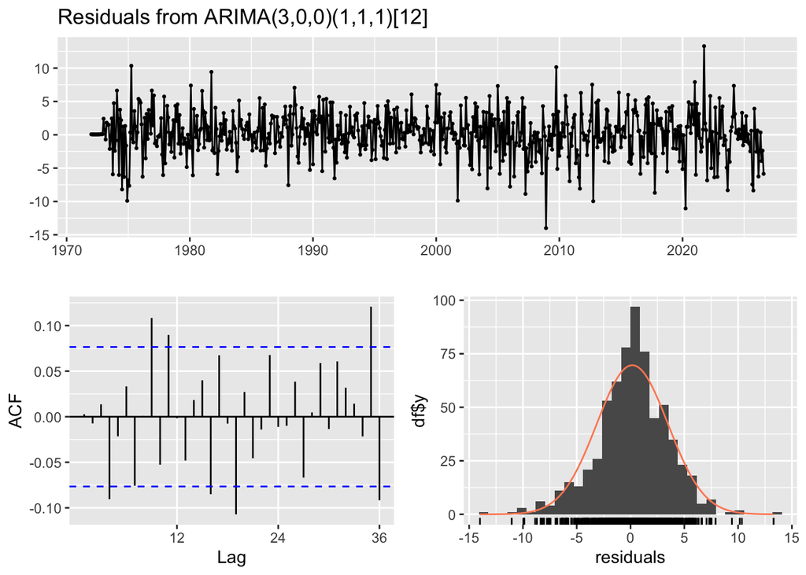

```
##
##  Ljung-Box test
##
## data:  Residuals from ARIMA(3,0,0)(1,1,1)[12]
## Q* = 49.366, df = 19, p-value = 0.0001624
##
## Model df: 5.   Total lags used: 24
```

```r
checkresiduals(final_fit)
```

```r
final_forecast <- forecast(final_fit, h = 12)
final_forecast
```

```
##          Point Forecast    Lo 80     Hi 80    Lo 95     Hi 95
## Sep 2026       82.38101 78.08211  86.67990 75.80642  88.95560
## Oct 2026       90.67434 85.37653  95.97216 82.57203  98.77665
## Nov 2026       93.49360 87.63897  99.34824 84.53971 102.44750
## Dec 2026       95.29881 88.93100 101.66661 85.56008 105.03753
## Jan 2027       85.53543 78.75444  92.31642 75.16480  95.90606
## Feb 2027       85.64531 78.53665  92.75397 74.77355  96.51707
## Mar 2027       84.73115 77.35134  92.11096 73.44471  96.01760
## Apr 2027       81.07992 73.47418  88.68566 69.44795  92.71189
## May 2027       78.28646 70.49206  86.08087 66.36595  90.20698
## Jun 2027       77.91080 69.95786  85.86373 65.74783  90.07376
## Jul 2027       76.50373 68.41702  84.59044 64.13618  88.87129
## Aug 2027       80.60048 72.40057  88.80040 68.05979  93.14118
```

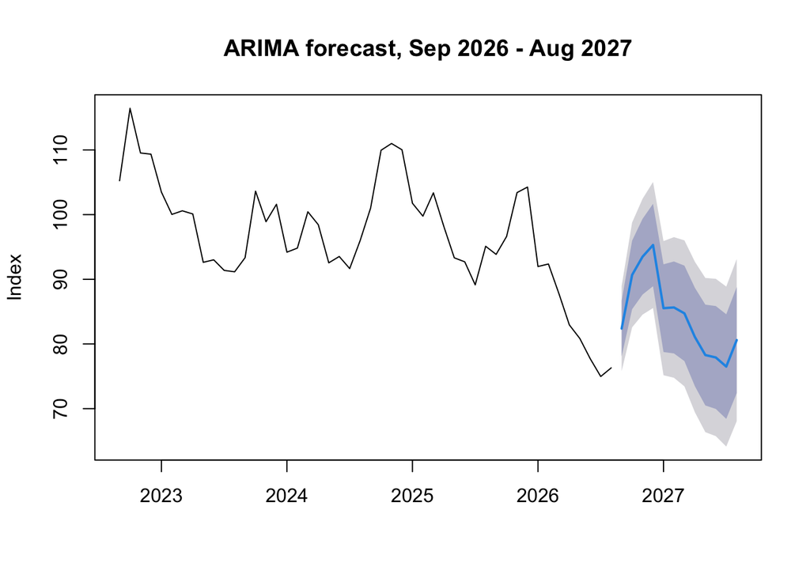

```r
plot(final_forecast, include = 48, main = "ARIMA forecast, Sep 2026 - Aug 2027", ylab = "Index")
```

```r
mean(final_forecast$mean)
```

```
## [1] 84.34509
```

```r
mean(window(candy_ts, start = c(2025, 9)))
```

```
## [1] 88.58716
```

```r
mean(window(final_forecast$mean, start = c(2026, 10), end = c(2026, 12)))
```

```
## [1] 93.15558
```

```r
mean(window(candy_ts, start = c(2025, 10), end = c(2025, 12)))
```

```
## [1] 101.4294
```

**Conclusion:** ARIMA(3,0,0)(1,1,1)[12] has the lowest average error across the ten one-year tests (RMSE 5.95) and the cleanest residuals of the six models. It forecasts an average index of 84.3 for Sep 2026 – Aug 2027, 4.8% below the last 12 months, with an Oct–Dec 2026 holiday peak averaging 93.2, down 8% from 2025.